# LiveAssignment4

William Arnost

June 3, 2019

# 1. Harry Potter Cast (50%)

There is a lot of text associated with this question. We are scraping the cast list for Harry Potter 2 and cleaning the data. Here is a summary of the requrirements:  
1. Scrape the data from the provided link and put it into a data table  
2. Clean the table  
a. It should not have blank or otherwise useless data  
b. It should have intuitive column names (ideally 2 to start - Actor and Character)  
c. Fix the issue with Mr. Warwick’s double character role  
d. remove the “Rest of cast…” observation that doesn’t belong  
3. Split the actor names into first name / surname  
4. Display the first 10 rows of the cleaned data, 3 relevant columns only.

Here are the packages and URL I will be using

```r
library(tidyverse)
library(rvest)
library(humaniformat)
library(stringi)

url<-"https://www.imdb.com/title/tt1201607/fullcredits?ref_=tt_ql_1"
```

Here I am extracting the table from the html, checking the values, and doing some cleaning

```r
## Read the html, extract the table nodes, then the specific table of interest
cast_list <- read_html(url) %>% html_nodes(.,"table") %>% html_table %>%.[[3]]

##Take a peek at the data
str(cast_list)
```

```
## 'data.frame':    152 obs. of  4 variables:
##  $ X1: chr  "" "" "" "" ...
##  $ X2: chr  "" "Ralph Fiennes" "Michael Gambon" "Alan Rickman" ...
##  $ X3: chr  "" "..." "..." "..." ...
##  $ X4: chr  "" "Lord Voldemort" "Professor Albus Dumbledore" "Professor Severus Snape" ...
```

```r
## Make sure X1 and X3 have no meaningful data
table(cast_list$X1)
```

```
##
##                                     Rest of cast listed alphabetically:
##                                 151                                   1
```

```r
table(cast_list$X3)
```

```
##
##                                                                     ...
##                                   1                                 150
## Rest of cast listed alphabetically:
##                                   1
```

```r
## Get rid of X1 and X3
cast_list$X1 <- NULL
cast_list$X3 <- NULL

## Assign meaningful names
names(cast_list) <- c("Actor","Character")

##Remove junk rows and remove extra spaces and \n from Character field
cast_list_filtered <- cast_list %>% filter(Actor != "",Actor !="Rest of cast listed alphabetically:")
cast_list_filtered$Character <- str_squish(cast_list_filtered$Character)
str(cast_list_filtered)
```

```
## 'data.frame':    150 obs. of  2 variables:
##  $ Actor    : chr  "Ralph Fiennes" "Michael Gambon" "Alan Rickman" "Daniel Radcliffe" ...
##  $ Character: chr  "Lord Voldemort" "Professor Albus Dumbledore" "Professor Severus Snape" "Harry Potter" ...
```

```r
head(cast_list_filtered,10)
```

```
##               Actor                            Character
## 1     Ralph Fiennes                       Lord Voldemort
## 2    Michael Gambon           Professor Albus Dumbledore
## 3      Alan Rickman              Professor Severus Snape
## 4  Daniel Radcliffe                         Harry Potter
## 5      Rupert Grint                          Ron Weasley
## 6       Emma Watson                     Hermione Granger
## 7      Evanna Lynch                        Luna Lovegood
## 8  Domhnall Gleeson                         Bill Weasley
## 9    Clémence Poésy                       Fleur Delacour
## 10    Warwick Davis Griphook / Professor Filius Flitwick
```

Names are super tricky. I am going to use a parse function from the humaniformat package. It doesn’t handle accents well so I need to remove those, I hope no one is offended.

```r
## Removing Accents, then parsing names
no_accents <- stri_trans_general(cast_list_filtered$Actor,"Latin-ASCII")
parsed_names <- parse_names(no_accents)

## If there is a middle name, combine with the first name.
firstName <- ifelse(is.na(parsed_names$middle_name),
                    parsed_names$first_name,
                    paste(parsed_names$first_name,parsed_names$middle_name)
                    )
lastName <- parsed_names$last_name

## Add the clean names to the previous data frame
cast_list_addNames <- cast_list_filtered %>% add_column(FirstName = firstName, Surname = lastName)
head(cast_list_addNames)
```

```
##              Actor                  Character FirstName   Surname
## 1    Ralph Fiennes             Lord Voldemort     Ralph   Fiennes
## 2   Michael Gambon Professor Albus Dumbledore   Michael    Gambon
## 3     Alan Rickman    Professor Severus Snape      Alan   Rickman
## 4 Daniel Radcliffe               Harry Potter    Daniel Radcliffe
## 5     Rupert Grint                Ron Weasley    Rupert     Grint
## 6      Emma Watson           Hermione Granger      Emma    Watson
```

Homenum revelio. Here is my cleaned data.

```r
cast_list_final <- cast_list_addNames %>% select(FirstName, Surname, Character)
head(cast_list_final,10)
```

```
##    FirstName   Surname                            Character
## 1      Ralph   Fiennes                       Lord Voldemort
## 2    Michael    Gambon           Professor Albus Dumbledore
## 3       Alan   Rickman              Professor Severus Snape
## 4     Daniel Radcliffe                         Harry Potter
## 5     Rupert     Grint                          Ron Weasley
## 6       Emma    Watson                     Hermione Granger
## 7     Evanna     Lynch                        Luna Lovegood
## 8   Domhnall   Gleeson                         Bill Weasley
## 9   Clemence     Poesy                       Fleur Delacour
## 10   Warwick     Davis Griphook / Professor Filius Flitwick
```

# 2. SportsBall (50%)

There is a lot of text associated with this question. We are scraping the shooting statistics for the San Antonio Spurs and cleaning the data. Here is a summary of the requrirements:  
1. Scrape the shooting statistics table for the San Antonio Spurs  
2. Clean the table so it shows one row per player. Make sure to avoid blank data, extra column names, and get rid of the total row.  
3. Split the player name into name and position  
4. verify numeric columns are numeric  
5. Create a colorful bar chart that shows the Field Goals Percentage Per Game for each person.  
a. Informative Title, centered  
b. Relevant x and y axis labels (not simply variables names!)  
c. Human-readable axes with no overlap  
d. Color the columns by the team member’s position

First step, get the html data, parse our the tables and get them into data frames.

```r
url <- "http://www.espn.com/nba/team/stats/_/name/sa/san-antonio-spurs"

## Read the html, get the table nodes, put the data into tables.
html_tables <- read_html(url) %>% html_nodes(.,"table") %>% html_table(., fill = TRUE)

## Extract the desired info
stats <- data.frame(html_tables[8])
players <- data.frame(html_tables[6])
```

Now lets combine the Stats and Players table, then separate name and position

```r
names(players) <- "Player"
shooting_stats <- cbind(players,stats) %>% filter(Player != "Total")

## This removes the last word from the name, getting rid of position
shooting_stats$Name = word(shooting_stats$Player,1,-2)

## This grabs the last word, which is the position
shooting_stats$Position = word(shooting_stats$Player,-1,-1)

## Reordering the columns
shooting_stats_final <- shooting_stats %>% select(Name,Position,2:14)
str(shooting_stats_final)
```

```
## 'data.frame':    13 obs. of  15 variables:
##  $ Name    : chr  "DeMar DeRozan" "LaMarcus Aldridge" "Derrick White" "Rudy Gay" ...
##  $ Position: chr  "SG" "C" "PG" "SF" ...
##  $ FGM     : num  8.3 7.9 5.9 4 3.9 3.3 2 2 1 1.2 ...
##  $ FGA     : num  17 17.3 10.7 10 8 5.1 5.4 6.1 3 2 ...
##  $ FG.     : num  48.7 45.5 54.7 40 48.2 63.9 36.8 32.6 33.3 60 ...
##  $ X3PM    : num  0 0.4 0.7 1.1 2.1 0 1.1 0.4 0.6 0 ...
##  $ X3PA    : num  0.1 1.6 2.4 2.7 4.4 0.1 3 3.1 2.2 0.2 ...
##  $ X3P.    : num  0 27.3 29.4 42.1 48.4 0 38.1 13.6 27.3 0 ...
##  $ FTM     : num  5.4 3.9 2.7 2 0.9 0.7 0.7 0.9 0.6 0.2 ...
##  $ FTA     : num  6.3 4.7 3.7 2.4 1.3 1.3 0.9 1.4 1 0.4 ...
##  $ FT.     : num  86.4 81.8 73.1 82.4 66.7 55.6 83.3 60 60 50 ...
##  $ X2PM    : num  8.3 7.4 5.1 2.9 1.7 3.3 0.9 1.6 0.4 1.2 ...
##  $ X2PA    : num  16.9 15.7 8.3 7.3 3.6 5 2.4 3 0.8 1.8 ...
##  $ X2P.    : num  49.2 47.3 62.1 39.2 48 65.7 35.3 52.4 50 66.7 ...
##  $ SC.EFF  : num  1.29 1.16 1.41 1.11 1.34 ...
```

Notice in the previous table that str shows us the numeric columns are indeed numeric. Now lets make our colorful graph. I have rearranged the names to be in descending order by field goal percentage. All positions are represented in the top 5 so it seems like you can score from any position, at least for the Spurs.

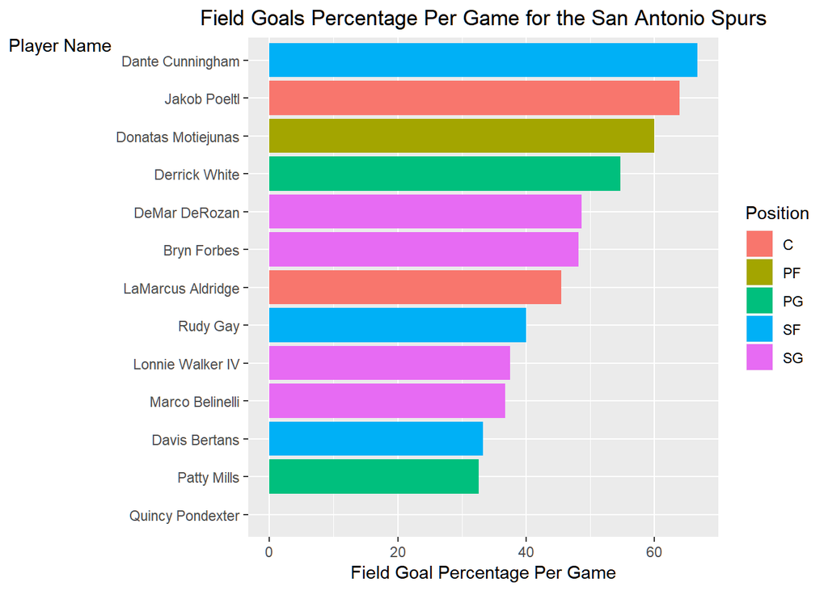

```r
ggplot(shooting_stats_final,aes(x=reorder(Name,FG.), y=FG., fill=Position)) +
  geom_bar(stat = "identity") +
  coord_flip() +
  ggtitle("Field Goals Percentage Per Game for the San Antonio Spurs") +
  ylab("Field Goal Percentage Per Game") +
  xlab("Player Name") +
  theme(plot.title = element_text(hjust = 0.5),axis.title.y=element_text(angle=0,vjust=1))
```